# A3: Incarceration

### Introduction

An introduction of the problem domain and a description of the variable(s) you are choosing to analyze (and why!)

As modern day awareness around data feminism is rising, discussing what race or gender plays a role in the rate of incarceration in the United States would be a relevant topic to explore. Using the data set about prison population per county/state provided by the Vera Institute, this report hopes to analyze the trends and help identify possible solutions to the disproportionately high rates for certain races especially the Black population. To make a deeper analysis of the dataset, this report will pay particular attention to the incarcerated population among different races which include, AAPI, Black, Latinx, Native, Other, and White as well as the differentiating the data of female to male prisoners.

### Summary Information

Write a summary paragraph of findings that includes the 5 values calculated from your summary information R script

For finding the 5 summary values, I decided to find the total number of incarcerated people until the year 2016, the female and male counts of this total population, and the total black or white prisoners there are. The reason why I chose year 2016 is because it is the most latest year that contains data on the total incarcerations as well their distribution depending on gender of race. However, there were still a lot of missing values(NA) so the numbers don’t add up perfectly, but we could see the overall trend and spread of the data. Below is the 5 values I calculated for year 2016:

- total_incarcerated = 1,046,289
- total_female = 77,207
- total_male = 955,982
- total_black = 405,266
- total_white = 415,876

### The Dataset

Who collected the data?

How was the data collected or generated?

Why was the data collected?

How many observations (rows) are in your data?

How many features (columns) are in the data?

What, if any, ethical questions or questions of power do you need to consider when working with this data?

What are possible limitations or problems with this data? (at least 200 words)

- The data was collected by Vera Institute. This data was collected with information from federal, state, and local organizations about the status of incarceration in their prisons. Some data include numbers on total prisoners, female and male prisoners, and the various races of those prisoners. According to the Vera Institute, the data was collected to “transform the criminal legal and immigration systems until they’re fair for all.” Through collecting and analyzing the data, they hope to achieve this mission. There are a total of 153,811 observations and a total of 36 columns in this dataset. Some possible limitations or problems with this data are that it has a lot of missing data on prisoners after the year 2016 as well as non-disclosed information on the gender distribution of prisoners which I believe could have been influenced by individual state departments for privacy or LQBTQ+ inclusive purposes. Some ethical questions surrounding this dataset are how were the privacy of prisoners protected? What degrees of crime did individual prisoners commit where it could be categorized to the year of prison they have been convicted for or be categorized into low, medium, and high degrees of subjective categorization of crime.

### Trends Over Time Chart

The first chart that you will create and include will show the trend over time of your variable/topic. Think carefully about what you want to communicate to your user (you may have to find relevant trends in the dataset first!).

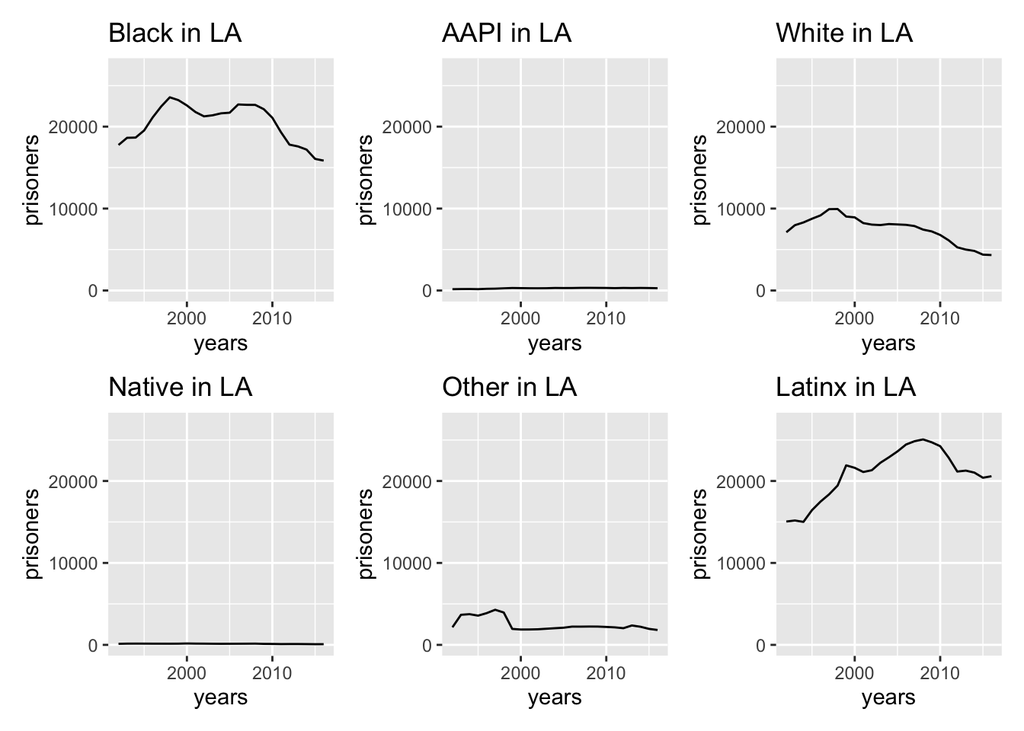

### Variable Comparison Chart

The second chart that you will create and include will show how two different (continuous) variables are related to one another. Again, think carefully about what such a comparison means and what you want to communicate to your user (you may have to find relevant trends in the dataset first!).

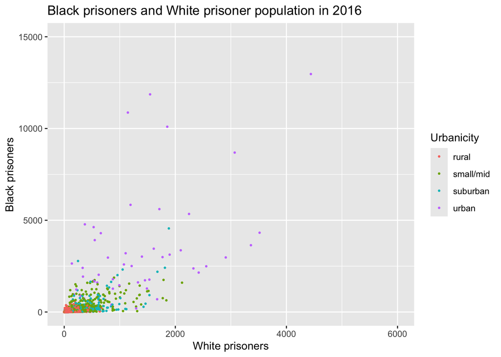

### Map

Include a chart. Make sure to describe why you included the chart, and what patterns emerged

The last chart that you will create and include will show how a variable is distributed geographically. Again, think carefully about what such a comparison means and what you want to communicate to your user (you may have to find relevant trends in the dataset first!)

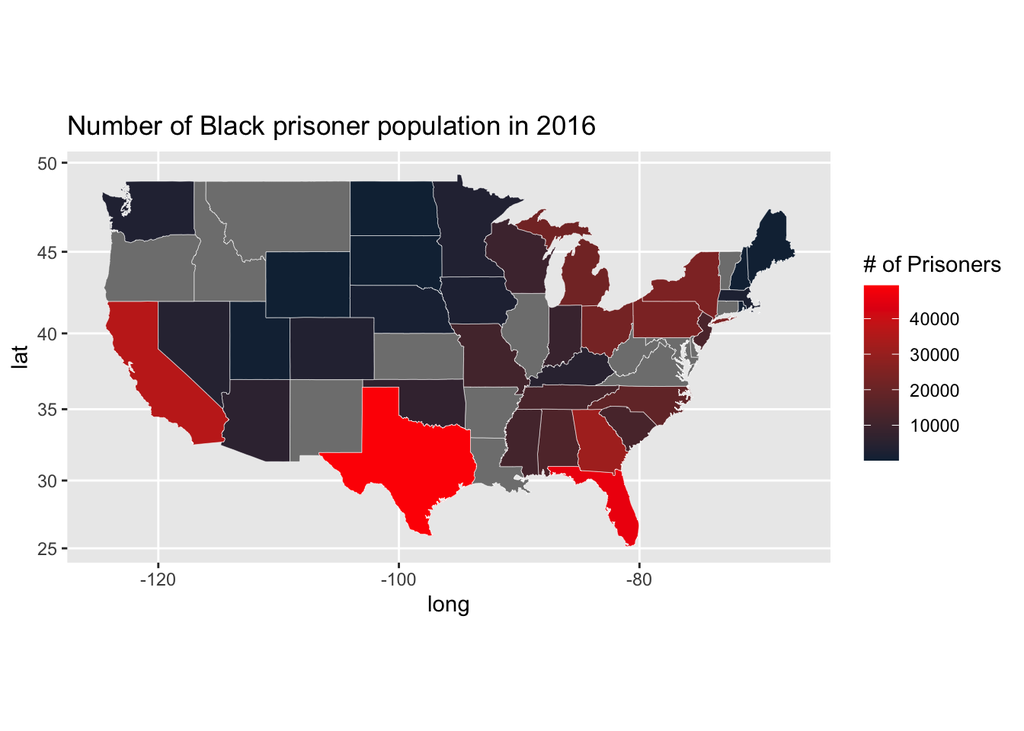

For the visualization of my data, I chose to visualize the black prisoner population across the United States. I decided to do this because this visualization could potentially shed a light on if some convictions were made from the appearance of an individual than their actions. According to the map I generated, the overall pattern is that there are a lot of black prisoners near the East coast and also in California and Texas. From the color of the state, Texas, Florida, and California seems to be the states with the most number of black prisoners. In contrast, the west and midwest regions of the U.S seems to be the region with the least number of black prisoners.